# Ademola Ensemble Techniques

```python
# importing some important libraries.

import pandas            as pd
import numpy             as np
import matplotlib.pyplot as plt
import seaborn           as sns
import missingno         as msno


from sklearn.model_selection  import train_test_split
from sklearn.tree             import DecisionTreeRegressor
from sklearn.ensemble         import BaggingRegressor
from sklearn.ensemble         import RandomForestRegressor
from sklearn.metrics          import mean_absolute_error, mean_squared_error
from sklearn.model_selection  import GridSearchCV
from sklearn.ensemble         import AdaBoostRegressor
from sklearn.ensemble         import GradientBoostingRegressor
from xgboost                  import XGBRegressor

import warnings
warnings.filterwarnings('ignore')
```

```python
# reading the data and having a quick glace at the data.

def read_data(path):
    data = pd.read_csv(path)
    return data

data = read_data('SuperKart.csv')
data.head()
```

|  | Product_Id | Product_Weight | Product_Sugar_Content | Product_Allocated_Area | Product_Type | Product_MRP | Store_Id | Store_Establishment_Year | Store_Size | Store_Location_City_Type | Store_Type | Product_Store_Sales_Total |
| --- | --- | --- | --- | --- | --- | --- | --- | --- | --- | --- | --- | --- |
| 0 | FD6114 | 12.66 | Low Sugar | 0.027 | Frozen Foods | 117.08 | OUT004 | 2009 | Medium | Tier 2 | Supermarket Type2 | 2842.40 |
| 1 | FD7839 | 16.54 | Low Sugar | 0.144 | Dairy | 171.43 | OUT003 | 1999 | Medium | Tier 1 | Departmental Store | 4830.02 |
| 2 | FD5075 | 14.28 | Regular | 0.031 | Canned | 162.08 | OUT001 | 1987 | High | Tier 2 | Supermarket Type1 | 4130.16 |
| 3 | FD8233 | 12.10 | Low Sugar | 0.112 | Baking Goods | 186.31 | OUT001 | 1987 | High | Tier 2 | Supermarket Type1 | 4132.18 |
| 4 | NC1180 | 9.57 | No Sugar | 0.010 | Health and Hygiene | 123.67 | OUT002 | 1998 | Small | Tier 3 | Food Mart | 2279.36 |

```python
data.tail()
```

|  | Product_Id | Product_Weight | Product_Sugar_Content | Product_Allocated_Area | Product_Type | Product_MRP | Store_Id | Store_Establishment_Year | Store_Size | Store_Location_City_Type | Store_Type | Product_Store_Sales_Total |
| --- | --- | --- | --- | --- | --- | --- | --- | --- | --- | --- | --- | --- |
| 8758 | NC7546 | 14.80 | No Sugar | 0.016 | Health and Hygiene | 140.53 | OUT004 | 2009 | Medium | Tier 2 | Supermarket Type2 | 3806.53 |
| 8759 | NC584 | 14.06 | No Sugar | 0.142 | Household | 144.51 | OUT004 | 2009 | Medium | Tier 2 | Supermarket Type2 | 5020.74 |
| 8760 | NC2471 | 13.48 | No Sugar | 0.017 | Health and Hygiene | 88.58 | OUT001 | 1987 | High | Tier 2 | Supermarket Type1 | 2443.42 |
| 8761 | NC7187 | 13.89 | No Sugar | 0.193 | Household | 168.44 | OUT001 | 1987 | High | Tier 2 | Supermarket Type1 | 4171.82 |
| 8762 | FD306 | 14.73 | Low Sugar | 0.177 | Snack Foods | 224.93 | OUT002 | 1998 | Small | Tier 3 | Food Mart | 2186.08 |

```python
data.sample(10)
```

|  | Product_Id | Product_Weight | Product_Sugar_Content | Product_Allocated_Area | Product_Type | Product_MRP | Store_Id | Store_Establishment_Year | Store_Size | Store_Location_City_Type | Store_Type | Product_Store_Sales_Total |
| --- | --- | --- | --- | --- | --- | --- | --- | --- | --- | --- | --- | --- |
| 7899 | DR165 | 14.37 | Low Sugar | 0.066 | Soft Drinks | 167.02 | OUT001 | 1987 | High | Tier 2 | Supermarket Type1 | 4785.32 |
| 3193 | FD4780 | 14.35 | Regular | 0.064 | Canned | 194.49 | OUT001 | 1987 | High | Tier 2 | Supermarket Type1 | 4809.03 |
| 1962 | FD6514 | 15.97 | Regular | 0.057 | Fruits and Vegetables | 170.65 | OUT001 | 1987 | High | Tier 2 | Supermarket Type1 | 4686.15 |
| 4442 | FD2249 | 11.63 | reg | 0.045 | Frozen Foods | 139.50 | OUT004 | 2009 | Medium | Tier 2 | Supermarket Type2 | 3068.54 |
| 2881 | FD6056 | 12.74 | Regular | 0.033 | Baking Goods | 168.17 | OUT004 | 2009 | Medium | Tier 2 | Supermarket Type2 | 3904.67 |
| 4360 | FD7032 | 12.77 | Regular | 0.017 | Starchy Foods | 151.44 | OUT004 | 2009 | Medium | Tier 2 | Supermarket Type2 | 3568.94 |
| 6736 | DR6917 | 13.72 | Low Sugar | 0.051 | Hard Drinks | 144.15 | OUT004 | 2009 | Medium | Tier 2 | Supermarket Type2 | 3636.68 |
| 2887 | NC5280 | 10.18 | No Sugar | 0.062 | Health and Hygiene | 138.80 | OUT004 | 2009 | Medium | Tier 2 | Supermarket Type2 | 2725.38 |
| 4859 | FD3966 | 8.42 | Regular | 0.041 | Canned | 106.32 | OUT002 | 1998 | Small | Tier 3 | Food Mart | 1663.94 |
| 7785 | FD7219 | 14.84 | Low Sugar | 0.064 | Dairy | 135.55 | OUT004 | 2009 | Medium | Tier 2 | Supermarket Type2 | 3712.61 |

```python
data.shape
```

```
(8763, 12)
```

```python
data.dtypes
```

```
Product_Id                    object
Product_Weight               float64
Product_Sugar_Content         object
Product_Allocated_Area       float64
Product_Type                  object
Product_MRP                  float64
Store_Id                      object
Store_Establishment_Year       int64
Store_Size                    object
Store_Location_City_Type      object
Store_Type                    object
Product_Store_Sales_Total    float64
dtype: object
```

```python
data.info()
```

```
<class 'pandas.core.frame.DataFrame'>
RangeIndex: 8763 entries, 0 to 8762
Data columns (total 12 columns):
 #   Column                     Non-Null Count  Dtype
---  ------                     --------------  -----
 0   Product_Id                 8763 non-null   object
 1   Product_Weight             8763 non-null   float64
 2   Product_Sugar_Content      8763 non-null   object
 3   Product_Allocated_Area     8763 non-null   float64
 4   Product_Type               8763 non-null   object
 5   Product_MRP                8763 non-null   float64
 6   Store_Id                   8763 non-null   object
 7   Store_Establishment_Year   8763 non-null   int64
 8   Store_Size                 8763 non-null   object
 9   Store_Location_City_Type   8763 non-null   object
 10  Store_Type                 8763 non-null   object
 11  Product_Store_Sales_Total  8763 non-null   float64
dtypes: float64(4), int64(1), object(7)
memory usage: 821.7+ KB
```

```python
# creating two separate dataframes for categorical and numerical features.

categorical_features = data.select_dtypes(include='object')
numerical_features   = data.select_dtypes(exclude='object')
```

```python
# showing some statistical analysis of the data like mean, std, min, max, and, count for the numeric features.

data.describe()
```

|  | Product_Weight | Product_Allocated_Area | Product_MRP | Store_Establishment_Year | Product_Store_Sales_Total |
| --- | --- | --- | --- | --- | --- |
| count | 8763.000000 | 8763.000000 | 8763.000000 | 8763.000000 | 8763.000000 |
| mean | 12.653792 | 0.068786 | 147.032539 | 2002.032751 | 3464.003640 |
| std | 2.217320 | 0.048204 | 30.694110 | 8.388381 | 1065.630494 |
| min | 4.000000 | 0.004000 | 31.000000 | 1987.000000 | 33.000000 |
| 25% | 11.150000 | 0.031000 | 126.160000 | 1998.000000 | 2761.715000 |
| 50% | 12.660000 | 0.056000 | 146.740000 | 2009.000000 | 3452.340000 |
| 75% | 14.180000 | 0.096000 | 167.585000 | 2009.000000 | 4145.165000 |
| max | 22.000000 | 0.298000 | 266.000000 | 2009.000000 | 8000.000000 |

```python
# showing some statistical analysis of the data like unique, top, frequency, and, count for the categorical features.

data.describe(include='object')
```

|  | Product_Id | Product_Sugar_Content | Product_Type | Store_Id | Store_Size | Store_Location_City_Type | Store_Type |
| --- | --- | --- | --- | --- | --- | --- | --- |
| count | 8763 | 8763 | 8763 | 8763 | 8763 | 8763 | 8763 |
| unique | 8763 | 4 | 16 | 4 | 3 | 3 | 4 |
| top | FD1393 | Low Sugar | Fruits and Vegetables | OUT004 | Medium | Tier 2 | Supermarket Type2 |
| freq | 1 | 4885 | 1249 | 4676 | 6025 | 6262 | 4676 |

### Exploratory Data Analysis and Insights

- Use appropriate visualizations to identify the patterns and insights - Key meaningful observations on individual variables and the relationship between variables

#### Problem definition

Sales forecasting is the process of predicting how much revenue a company, team, or person will generate within a specific timeframe. Every organization or company wants to make an accurate and valid sales forecast because it is very helpful in making many decisions. An accurate sales forecast allows and helps companies to efficiently allocate resources for their future growth and manage their cash flow.

Sales forecasting is both a science and an art. Decision makers rely on these forecasts to plan for business expansion and to determine how to fuel the company’s growth. So, in many ways, sales forecasting affects everyone in the organization

#### Univariate analysis

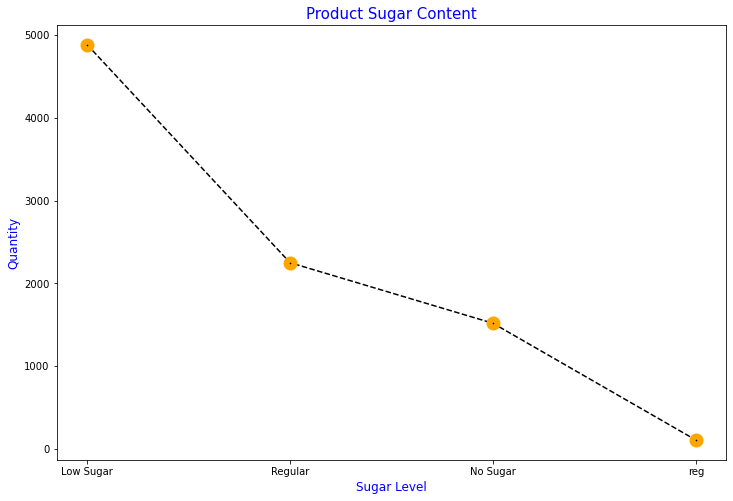

```python
plt.figure(figsize=(12, 8))
plt.plot(data.Product_Sugar_Content.value_counts(), marker='o', mec='orange', mew=8, ls='--', c='k')
plt.title("Product Sugar Content", fontsize=15, color='b')
plt.xlabel("Sugar Level", fontsize=12, color='b')
plt.ylabel("Quantity", fontsize=12, color='b')
plt.show()
```

From the above graph we can tell that more than half of the products have `Low Sugar`.

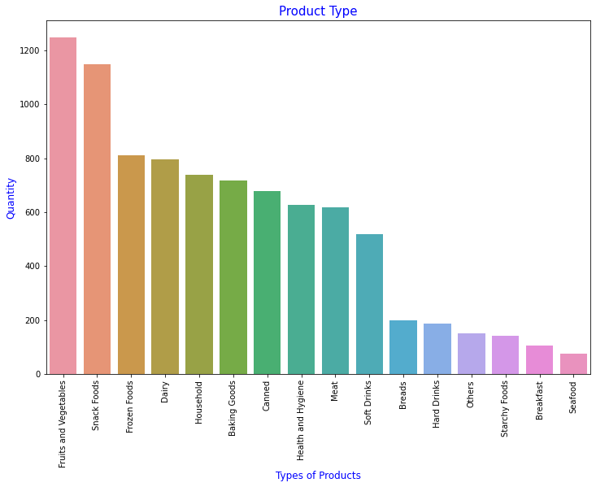

```python
plt.figure(figsize=(12, 8))
sns.countplot(categorical_features.Product_Type, order=categorical_features.Product_Type.value_counts().index)
plt.title("Product Type", fontsize=15, color='b')
plt.xlabel("Types of Products", fontsize=12, color='b')
plt.ylabel("Quantity", fontsize=12, color='b')
plt.xticks(rotation=90)
plt.show()
```

`Fruits and Vegetables`, `Snack Foods`, `Frozen Foods`, and `Dairy` are the most sold products and these four products alone cover almost `50%` of the sold products. This makes sense cause these are the items that are used on daily basis i.e. `Fruits and Vegetables` and `Dairy`.

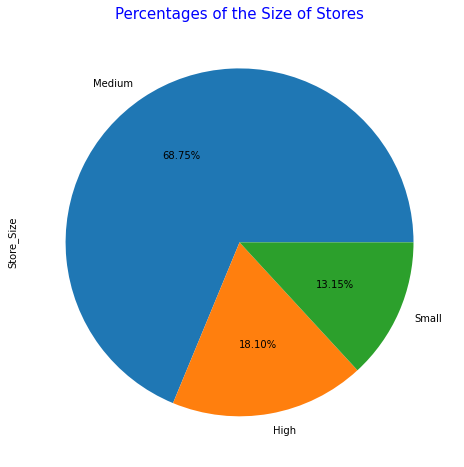

```python
data.Store_Size.value_counts().plot(kind = "pie", legend = False, autopct = "%1.2f%%", fontsize = 10, figsize=(8,8))
plt.title("Percentages of the Size of Stores", loc = "center", c='b', size=15)
plt.show()
```

The given dataset had `3` types of `Store Size` among which `medium` size store were `68.75%`. Most of the stores are `medium` in size.

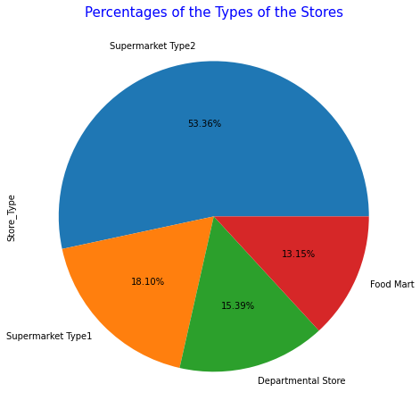

```python
data.Store_Type.value_counts().plot(kind = "pie", legend = False, autopct = "%1.2f%%", fontsize = 10, figsize=(8,8))
plt.title("Percentages of the Types of the Stores", loc = "center", c='b', size=15)
plt.show()
```

Most of the type of store is `Super Market` because almost `72%` of the stores are type of `Supermarket`, either `Supermaket type1` or `Supermarket type 2`

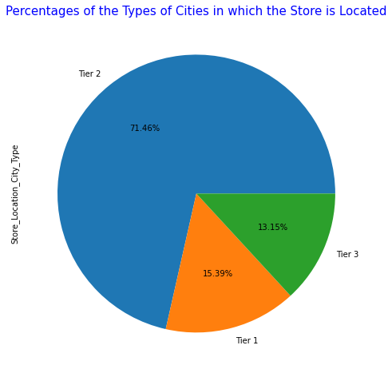

```python
data.Store_Location_City_Type.value_counts().plot(kind = "pie", legend = False, autopct = "%1.2f%%", fontsize = 10, figsize=(8,8))
plt.title("Percentages of the Types of Cities in which the Store is Located", loc = "center", c='b', size=15)
plt.show()
```

Most of the stores are located in `Tier 2`. `Tier 2` alone covers `71%` of all the stores.

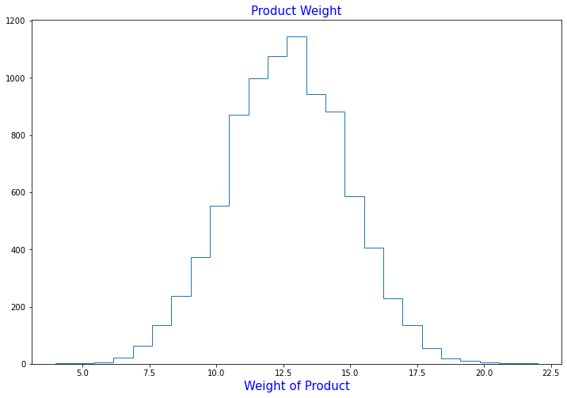

```python
plt.figure(figsize=(12, 8))
plt.hist(numerical_features.Product_Weight, histtype='step', bins=25)
plt.title("Product Weight", size=15, c='b')
plt.xlabel("Weight of Product", size=15, c='b')
plt.show()
```

We can see, in the above graph, that most of our products weigh around `11` to `14`. The weight of the majority of the products `12` which is also the mean of the `Product Weight`. Mean of the `Product Weight` is `12.63`.

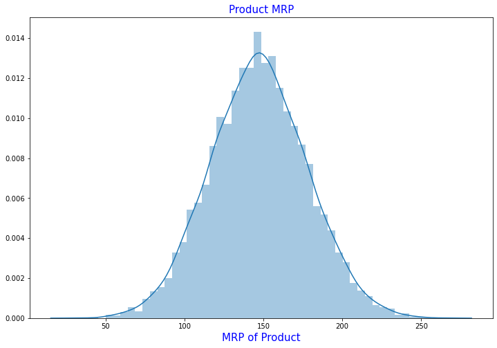

```python
plt.figure(figsize=(12, 8))
sns.distplot(numerical_features.Product_MRP)
plt.title("Product MRP", size=15, c='b')
plt.xlabel("MRP of Product", size=15, c='b')
plt.show()
```

We can see, in the above graph, that the `MRP` of most of the products is around `110` to `180`. The weight of the majority of the products `150` which is also the mean of the `Product Weight`. Mean of the `Product Weight` is `147`.

#### Bivariate analysis

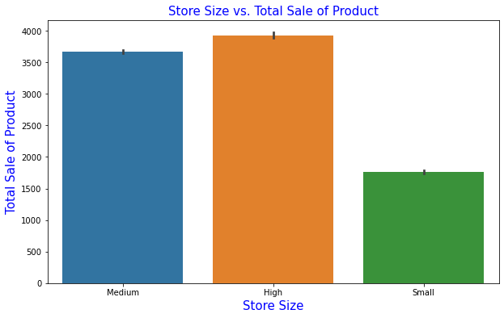

```python
plt.figure(figsize=(10, 6))
sns.barplot(x='Store_Size', y='Product_Store_Sales_Total', data=data)
plt.title("Store Size vs. Total Sale of Product", size=15, c='b')
plt.xlabel("Store Size", size=15, c='b')
plt.ylabel("Total Sale of Product", size=15, c='b')
plt.show()
```

From the above graph, we can tell that the bigger the size of the store the more the sale of the store. Stores of size `High` has the most sales while stores of the size `Small` has the least sales. This makes sense because in a `High Size Store` you can keep more products and thus chances of selling is more.

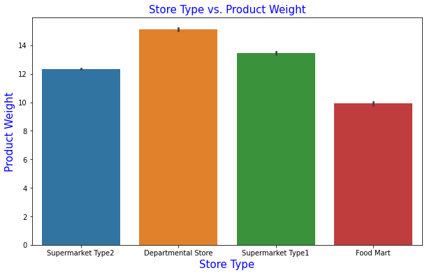

```python
plt.figure(figsize=(10, 6))
sns.barplot(x='Store_Type', y='Product_Weight', data=data)
plt.title("Store Type vs. Product Weight", size=15, c='b')
plt.xlabel("Store Type", size=15, c='b')
plt.ylabel("Product Weight", size=15, c='b')
plt.show()
```

`Departmental Store` and `Supermaket Type1` are the types of store having heavy product. `Food Mart` has the product with least weight and this is true because Food items aren't normally that heavy.

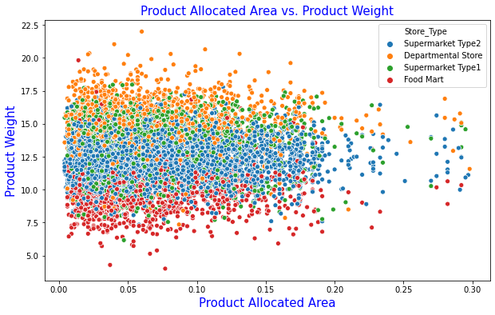

```python
plt.figure(figsize=(10, 6))
sns.scatterplot(x='Product_Allocated_Area', y='Product_Weight', hue='Store_Type', data=data)
plt.title("Product Allocated Area vs. Product Weight", size=15, c='b')
plt.xlabel("Product Allocated Area", size=15, c='b')
plt.ylabel("Product Weight", size=15, c='b')
plt.show()
```

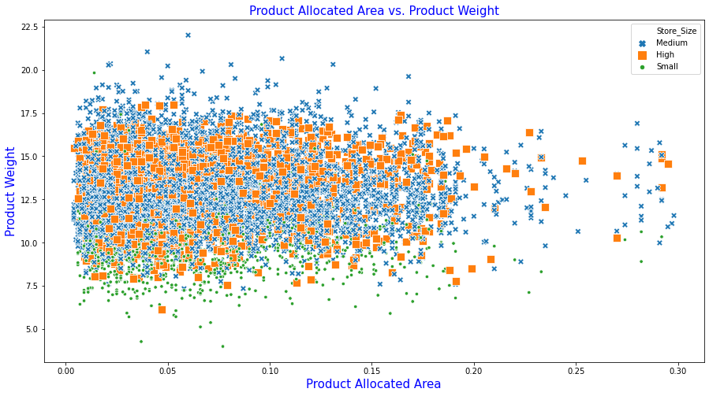

```python
plt.figure(figsize=(15, 8))
sns.scatterplot(x='Product_Allocated_Area', y='Product_Weight', data=data, size='Store_Size',
                legend='full', size_order=['Medium', 'High', 'Small'], sizes=[60, 100, 20], style='Store_Size',
                hue='Store_Size', markers=['X', 's', 'o'])
plt.title("Product Allocated Area vs. Product Weight", size=15, c='b')
plt.xlabel("Product Allocated Area", size=15, c='b')
plt.ylabel("Product Weight", size=15, c='b')
plt.show()
```

### Data pre-processing --> 5

- Prepare the data for analysis - Missing value Treatment (if needed) - Outlier Detection(treat, if needed- why or why not ), - Feature Engineering (if possible) - Prepare data for modeling

#### Missing value Treatment

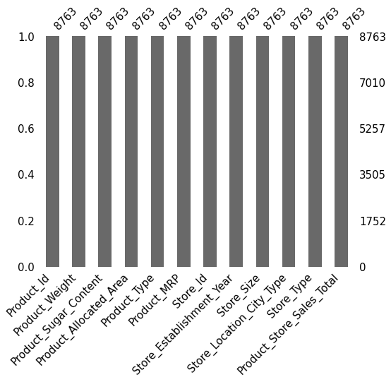

```python
msno.bar(data, figsize=(8,6), fontsize=15)
plt.show()
```

There is no missing value in our dataset and it can be seen in the graph above.

```python
data.isnull().sum()
```

```
Product_Id                   0
Product_Weight               0
Product_Sugar_Content        0
Product_Allocated_Area       0
Product_Type                 0
Product_MRP                  0
Store_Id                     0
Store_Establishment_Year     0
Store_Size                   0
Store_Location_City_Type     0
Store_Type                   0
Product_Store_Sales_Total    0
dtype: int64
```

#### Outlier Detection

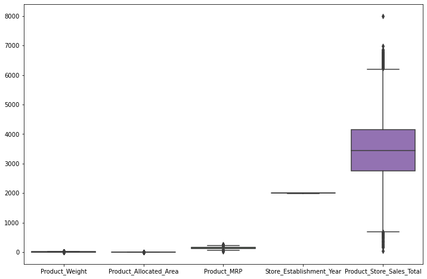

```python
plt.figure(figsize=(12, 8))
sns.boxplot(data = numerical_features)
```

```python
def remove_outliers(data, col):
    third_quartile = np.quantile(data[col], 0.75)
    first_quartile = np.quantile(data[col], 0.25)
    inter_quartile_range = third_quartile - first_quartile

    print("IQR value for column %s is: %s" % (col, inter_quartile_range))
    global outlier_free_list
    global filtered_data

    lower_range = first_quartile - 1.5 * inter_quartile_range
    upper_range = third_quartile + 1.5 * inter_quartile_range
    outlier_free_list = [x for x in data[col] if ((x > lower_range) & (x < upper_range))]
    filtered_data = data.loc[data[col].isin(outlier_free_list)]

    return filtered_data
```

```python
for i in numerical_features.columns:
    if i == data.columns[0]:
        remove_outliers(data, i)
    else:
        remove_outliers(data, i)
```

```
IQR value for column Product_Weight is: 3.0299999999999994
IQR value for column Product_Allocated_Area is: 0.065
IQR value for column Product_MRP is: 41.42500000000001
IQR value for column Store_Establishment_Year is: 11.0
IQR value for column Product_Store_Sales_Total is: 1383.4499999999998
```

```python
# Assigning filtered data back to our original variable
cleanded_data = filtered_data
print("Shape of data after outlier removal is: ", cleanded_data.shape)
```

```
Shape of data after outlier removal is:  (8644, 12)
```

```python
data.shape[0] - cleanded_data.shape[0]
```

```
119
```

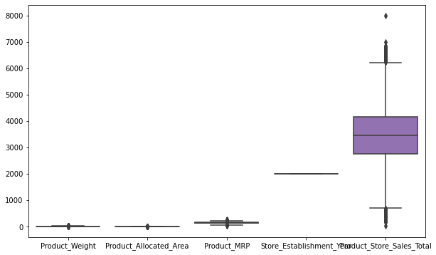

```python
plt.figure(figsize=(10, 6))
sns.boxplot(data = data)
```

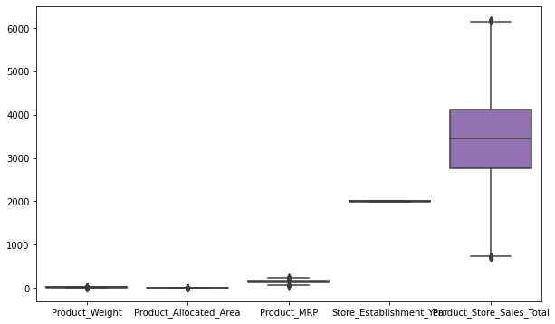

```python
plt.figure(figsize=(10, 6))
sns.boxplot(data = cleanded_data)
```

```python
cleanded_data.head()
```

|  | Product_Id | Product_Weight | Product_Sugar_Content | Product_Allocated_Area | Product_Type | Product_MRP | Store_Id | Store_Establishment_Year | Store_Size | Store_Location_City_Type | Store_Type | Product_Store_Sales_Total |
| --- | --- | --- | --- | --- | --- | --- | --- | --- | --- | --- | --- | --- |
| 0 | FD6114 | 12.66 | Low Sugar | 0.027 | Frozen Foods | 117.08 | OUT004 | 2009 | Medium | Tier 2 | Supermarket Type2 | 2842.40 |
| 1 | FD7839 | 16.54 | Low Sugar | 0.144 | Dairy | 171.43 | OUT003 | 1999 | Medium | Tier 1 | Departmental Store | 4830.02 |
| 2 | FD5075 | 14.28 | Regular | 0.031 | Canned | 162.08 | OUT001 | 1987 | High | Tier 2 | Supermarket Type1 | 4130.16 |
| 3 | FD8233 | 12.10 | Low Sugar | 0.112 | Baking Goods | 186.31 | OUT001 | 1987 | High | Tier 2 | Supermarket Type1 | 4132.18 |
| 4 | NC1180 | 9.57 | No Sugar | 0.010 | Health and Hygiene | 123.67 | OUT002 | 1998 | Small | Tier 3 | Food Mart | 2279.36 |

```python
cleanded_data.shape
```

```
(8644, 12)
```

#### Feature Engineering

```python
numerical_features   = cleanded_data.select_dtypes(exclude='object')
categorical_features = cleanded_data.select_dtypes(include='object')
```

```python
categorical_features.head()
```

|  | Product_Id | Product_Sugar_Content | Product_Type | Store_Id | Store_Size | Store_Location_City_Type | Store_Type |
| --- | --- | --- | --- | --- | --- | --- | --- |
| 0 | FD6114 | Low Sugar | Frozen Foods | OUT004 | Medium | Tier 2 | Supermarket Type2 |
| 1 | FD7839 | Low Sugar | Dairy | OUT003 | Medium | Tier 1 | Departmental Store |
| 2 | FD5075 | Regular | Canned | OUT001 | High | Tier 2 | Supermarket Type1 |
| 3 | FD8233 | Low Sugar | Baking Goods | OUT001 | High | Tier 2 | Supermarket Type1 |
| 4 | NC1180 | No Sugar | Health and Hygiene | OUT002 | Small | Tier 3 | Food Mart |

As we can see in the above dataframe, the `Product_Id` and `Store_Id` aren't that much useful for the model because the `Product_Id` is a unique value for each product and it is also of type `object`, so we'll get almost `8763` different values for this column while converting it to a numerical one. The `Store_Id` column is also not that useful for further analysis and model building, so removing these two columns from our dataset will result better in model performance.

```python
categorical_features.drop(['Product_Id', 'Store_Id'], axis=1, inplace=True)

categorical_features.head()
```

|  | Product_Sugar_Content | Product_Type | Store_Size | Store_Location_City_Type | Store_Type |
| --- | --- | --- | --- | --- | --- |
| 0 | Low Sugar | Frozen Foods | Medium | Tier 2 | Supermarket Type2 |
| 1 | Low Sugar | Dairy | Medium | Tier 1 | Departmental Store |
| 2 | Regular | Canned | High | Tier 2 | Supermarket Type1 |
| 3 | Low Sugar | Baking Goods | High | Tier 2 | Supermarket Type1 |
| 4 | No Sugar | Health and Hygiene | Small | Tier 3 | Food Mart |

```python
numerical_features.head()
```

|  | Product_Weight | Product_Allocated_Area | Product_MRP | Store_Establishment_Year | Product_Store_Sales_Total |
| --- | --- | --- | --- | --- | --- |
| 0 | 12.66 | 0.027 | 117.08 | 2009 | 2842.40 |
| 1 | 16.54 | 0.144 | 171.43 | 1999 | 4830.02 |
| 2 | 14.28 | 0.031 | 162.08 | 1987 | 4130.16 |
| 3 | 12.10 | 0.112 | 186.31 | 1987 | 4132.18 |
| 4 | 9.57 | 0.010 | 123.67 | 1998 | 2279.36 |

#### Preparing Data for Modeling

As we already know that computers or machines can't interpret or understand textual or categorical data. Therefore, converting the categorical features to numerical ones are must so that the computer can process it and the data is in a valid form for the algorithm to be fitted upon. Converting the categorical columns to numberical by changing it's type to `category` and then applying some category codes to it.

```python
categorical_features[['Product_Sugar_Content']] = categorical_features[['Product_Sugar_Content']].astype('category')
categorical_features[['Product_Type']] = categorical_features[['Product_Type']].astype('category')
categorical_features[['Store_Size']] = categorical_features[['Store_Size']].astype('category')
categorical_features[['Store_Location_City_Type']] = categorical_features[['Store_Location_City_Type']].astype('category')
categorical_features[['Store_Type']] = categorical_features[['Store_Type']].astype('category')

categorical_features.dtypes
```

```
Product_Sugar_Content       category
Product_Type                category
Store_Size                  category
Store_Location_City_Type    category
Store_Type                  category
dtype: object
```

The `dtypes` of the above features is now changed to `category`.

```python
categorical_features['Product_Sugar_Content'] = categorical_features['Product_Sugar_Content'].cat.codes
categorical_features['Product_Type'] = categorical_features['Product_Type'].cat.codes
categorical_features['Store_Size'] = categorical_features['Store_Size'].cat.codes
categorical_features['Store_Location_City_Type'] = categorical_features['Store_Location_City_Type'].cat.codes
categorical_features['Store_Type'] = categorical_features['Store_Type'].cat.codes

categorical_features.dtypes
```

```
Product_Sugar_Content       int8
Product_Type                int8
Store_Size                  int8
Store_Location_City_Type    int8
Store_Type                  int8
dtype: object
```

Finally, all the `categorical features` are now converted to `int8` and is now ready to be trained an algorith on it.

```python
categorical_features.sample(10)
```

|  | Product_Sugar_Content | Product_Type | Store_Size | Store_Location_City_Type | Store_Type |
| --- | --- | --- | --- | --- | --- |
| 2392 | 0 | 6 | 1 | 0 | 0 |
| 4308 | 0 | 13 | 0 | 1 | 2 |
| 626 | 2 | 4 | 1 | 1 | 3 |
| 3298 | 2 | 0 | 0 | 1 | 2 |
| 2209 | 0 | 6 | 1 | 0 | 0 |
| 539 | 0 | 10 | 2 | 2 | 1 |
| 7560 | 2 | 3 | 1 | 0 | 0 |
| 2863 | 0 | 3 | 1 | 0 | 0 |
| 8389 | 2 | 3 | 1 | 1 | 3 |
| 4139 | 0 | 6 | 1 | 1 | 3 |

```python
numerical_features.describe()
```

|  | Product_Weight | Product_Allocated_Area | Product_MRP | Store_Establishment_Year | Product_Store_Sales_Total |
| --- | --- | --- | --- | --- | --- |
| count | 8644.000000 | 8644.000000 | 8644.000000 | 8644.000000 | 8644.000000 |
| mean | 12.648223 | 0.068767 | 146.899971 | 2002.078783 | 3447.646827 |
| std | 2.179463 | 0.048245 | 30.128226 | 8.436513 | 1010.881798 |
| min | 5.130000 | 0.004000 | 51.900000 | 1987.000000 | 692.380000 |
| 25% | 11.150000 | 0.031000 | 126.207500 | 1998.000000 | 2764.685000 |
| 50% | 12.660000 | 0.056000 | 146.685000 | 2009.000000 | 3445.100000 |
| 75% | 14.160000 | 0.096000 | 167.310000 | 2009.000000 | 4118.582500 |
| max | 21.040000 | 0.298000 | 250.140000 | 2009.000000 | 6201.600000 |

```python
min_max_df = (numerical_features - numerical_features.min())/(numerical_features.max() - numerical_features.min())

min_max_df.head()
```

|  | Product_Weight | Product_Allocated_Area | Product_MRP | Store_Establishment_Year | Product_Store_Sales_Total |
| --- | --- | --- | --- | --- | --- |
| 0 | 0.473287 | 0.078231 | 0.328793 | 1.000000 | 0.390259 |
| 1 | 0.717159 | 0.476190 | 0.602956 | 0.545455 | 0.751039 |
| 2 | 0.575110 | 0.091837 | 0.555791 | 0.000000 | 0.624005 |
| 3 | 0.438089 | 0.367347 | 0.678017 | 0.000000 | 0.624372 |
| 4 | 0.279070 | 0.020408 | 0.362036 | 0.500000 | 0.288059 |

```python
min_max_df.describe()
```

|  | Product_Weight | Product_Allocated_Area | Product_MRP | Store_Establishment_Year | Product_Store_Sales_Total |
| --- | --- | --- | --- | --- | --- |
| count | 8644.000000 | 8644.000000 | 8644.000000 | 8644.000000 | 8644.000000 |
| mean | 0.472547 | 0.220298 | 0.479217 | 0.685399 | 0.500119 |
| std | 0.136987 | 0.164100 | 0.151979 | 0.383478 | 0.183489 |
| min | 0.000000 | 0.000000 | 0.000000 | 0.000000 | 0.000000 |
| 25% | 0.378378 | 0.091837 | 0.374836 | 0.500000 | 0.376152 |
| 50% | 0.473287 | 0.176871 | 0.478133 | 1.000000 | 0.499657 |
| 75% | 0.567568 | 0.312925 | 0.582173 | 1.000000 | 0.621903 |
| max | 1.000000 | 1.000000 | 1.000000 | 1.000000 | 1.000000 |

```python
# combining both the categorical and the numerical columns.

final_data = pd.concat([categorical_features, min_max_df], axis=1)

final_data.head()
```

|  | Product_Sugar_Content | Product_Type | Store_Size | Store_Location_City_Type | Store_Type | Product_Weight | Product_Allocated_Area | Product_MRP | Store_Establishment_Year | Product_Store_Sales_Total |
| --- | --- | --- | --- | --- | --- | --- | --- | --- | --- | --- |
| 0 | 0 | 5 | 1 | 1 | 3 | 0.473287 | 0.078231 | 0.328793 | 1.000000 | 0.390259 |
| 1 | 0 | 4 | 1 | 0 | 0 | 0.717159 | 0.476190 | 0.602956 | 0.545455 | 0.751039 |
| 2 | 2 | 3 | 0 | 1 | 2 | 0.575110 | 0.091837 | 0.555791 | 0.000000 | 0.624005 |
| 3 | 0 | 0 | 0 | 1 | 2 | 0.438089 | 0.367347 | 0.678017 | 0.000000 | 0.624372 |
| 4 | 1 | 8 | 2 | 2 | 1 | 0.279070 | 0.020408 | 0.362036 | 0.500000 | 0.288059 |

```python
final_data.shape
```

```
(8644, 10)
```

```python
# separating the predictors and target variable.

predictors = final_data.iloc[:, :-1]
target = final_data[['Product_Store_Sales_Total']]
```

```python
# splitting the data into x_train, x_test, y_train, and y_test.
# x_train and  y_train will be used for training the models while x_test and y_test will be used to test the model.

x_train, x_test, y_train, y_test = train_test_split(predictors, target, test_size=0.3, random_state=0)
```

```python
print("Size of x_train: ", x_train.shape)
print("Size of x_test:  ", x_test.shape)
print("Size of y_train: ", y_train.shape)
print("Size of y_test:  ", y_test.shape)
```

```
Size of x_train:  (6050, 9)
Size of x_test:   (2594, 9)
Size of y_train:  (6050, 1)
Size of y_test:   (2594, 1)
```

`x_train` and `y_train` will be used for training the model while `x_test` and `y_test` will be used for testing the performance of the model.

### Model building - Bagging

#### Bagging classifier

```python
# Decision Tree

decision_tree = DecisionTreeRegressor()
decision_tree.fit(x_train, y_train)
dt_prediction = decision_tree.predict(x_test)
print('mean_absolute_error for Decision Tree:', mean_absolute_error(y_test, dt_prediction))
```

```
mean_absolute_error for Decision Tree: 0.022937916254088746
```

```python
# Bagging Regressor

bagging       = BaggingRegressor()
bagging.fit(x_train, y_train)
bg_prediction = bagging.predict(x_test)
print('mean_absolute_error for Bagging:      ', mean_absolute_error(y_test, bg_prediction))
```

```
mean_absolute_error for Bagging:       0.0199936010682836
```

```python
# Random Forest

random_forest = RandomForestRegressor()
random_forest.fit(x_train, y_train)
rf_prediction = random_forest.predict(x_test)
print('mean_absolute_error for Random Forest:', mean_absolute_error(y_test, rf_prediction))
```

```
mean_absolute_error for Random Forest: 0.01824132019920222
```

```python
# creating a small dataframe for the performance of the above models in order to visualize them.

dict_performance = {'Model': ['Decision Tree', 'Bagging Regressor', 'Random Forest'],
                    'Error': [mean_absolute_error(y_test, dt_prediction), mean_absolute_error(y_test, bg_prediction),
                              mean_absolute_error(y_test, rf_prediction)]}
model_performance = pd.DataFrame(dict_performance)

model_performance
```

|  | Model | Error |
| --- | --- | --- |
| 0 | Decision Tree | 0.022938 |
| 1 | Bagging Regressor | 0.019994 |
| 2 | Random Forest | 0.018241 |

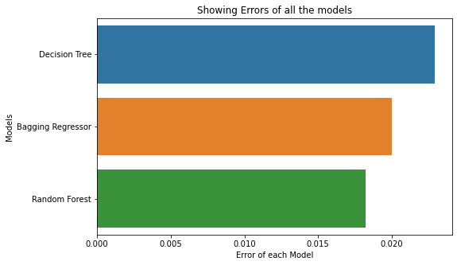

```python
plt.figure(figsize=(8, 5))
sns.barplot(x='Error', y='Model', data=model_performance, orient='h')
plt.title("Showing Errors of all the models")
plt.xlabel('Error of each Model')
plt.ylabel('Models')
plt.show()
```

From the above graph, we can see that `Random Forest` has the lowers error and hence the best model of them all.

#### Model Improvement - Bagging

```python
# Decision Tree

dt_parameters = {'splitter':['best', 'random'], 'criterion':['mse', 'friedman_mse', 'mae']}
dt_GridSearch = GridSearchCV(estimator = decision_tree, param_grid=dt_parameters)
dt_GridSearch.fit(x_train, y_train)

# printing the best score and best parameters
print("Best Score:  {}".format(dt_GridSearch.best_score_))
print("Best params: {}".format(dt_GridSearch.best_params_))
```

```
Best Score:  0.8710349189854709
Best params: {'criterion': 'friedman_mse', 'splitter': 'best'}
```

```python
# Bagging Regressor

bg_parameters = {'n_estimators':[750,1000]}
bg_GridSearch = GridSearchCV(estimator = bagging, param_grid = bg_parameters)
bg_GridSearch.fit(x_train, y_train)

# printing the best score and best parameters
print("Best Score:  {}".format(bg_GridSearch.best_score_))
print("Best params: {}".format(bg_GridSearch.best_params_))
```

```
Best Score:  0.9294999545926699
Best params: {'n_estimators': 750}
```

```python
# Random Forest

rf_parameters = {'n_estimators':[1000,1500], 'max_depth':[5,6]}
rf_GridSearch = GridSearchCV(estimator = random_forest, param_grid=rf_parameters)
rf_GridSearch.fit(x_train, y_train)

# printing the best score and best parameters
print("Best Score: {}".format(rf_GridSearch.best_score_))
print("Best params: {}".format(rf_GridSearch.best_params_))
```

```
Best Score: 0.9176097724009761
Best params: {'max_depth': 6, 'n_estimators': 1500}
```

```python
improved_decision_tree = DecisionTreeRegressor(criterion='absolute_error', splitter='random', min_samples_split=8)
improved_bagging       = BaggingRegressor(n_estimators=1000)
improved_random_forest = RandomForestRegressor(n_estimators=3000, min_samples_split=10)

improved_decision_tree.fit(x_train, y_train)
improved_bagging.fit(x_train, y_train)
improved_random_forest.fit(x_train, y_train)

improved_dt_prediction = improved_decision_tree.predict(x_test)
improved_bg_prediction = improved_bagging.predict(x_test)
improved_rf_prediction = improved_random_forest.predict(x_test)


print('mean_absolute_error for Decision Tree:', mean_absolute_error(y_test, improved_dt_prediction))
print('mean_absolute_error for Bagging:      ', mean_absolute_error(y_test, improved_bg_prediction))
print('mean_absolute_error for Random Forest:', mean_absolute_error(y_test, improved_rf_prediction))
```

```
mean_absolute_error for Decision Tree: 0.018531491781113657
mean_absolute_error for Bagging:       0.017819654390427698
mean_absolute_error for Random Forest: 0.017690113659772234
```

```python
improved_dict_performance = {'Model': ['Decision Tree', 'Bagging Regressor', 'Random Forest'],
                    'Error': [mean_absolute_error(y_test, improved_dt_prediction),
                              mean_absolute_error(y_test, improved_bg_prediction),
                              mean_absolute_error(y_test, improved_rf_prediction)]}
improved_model_performance = pd.DataFrame(improved_dict_performance)

improved_model_performance
```

|  | Model | Error |
| --- | --- | --- |
| 0 | Decision Tree | 0.018531 |
| 1 | Bagging Regressor | 0.017820 |
| 2 | Random Forest | 0.017690 |

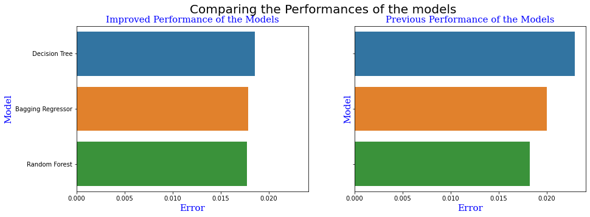

```python
fig, axes = plt.subplots(1, 2, figsize=(15, 5), sharey=True, sharex=True)
fig.suptitle('Comparing the Performances of the models', fontsize = 20, x=0.5, fontweight=500)

font1 = {'family':'serif','color':'blue','size':15}

sns.barplot(ax=axes[0], x='Error', y='Model', data = improved_model_performance, orient='h')
axes[0].set_title("Improved Performance of the Models", fontdict = font1)
axes[0].set_xlabel('Error', fontdict=font1)
axes[0].set_ylabel('Model', fontdict=font1)
# axes[0].xla

# plt.subplot(1, 2, 2)
sns.barplot(ax=axes[1], x='Error', y='Model', data = model_performance, orient='h')
axes[1].set_title("Previous Performance of the Models", fontdict = font1)
axes[1].set_xlabel('Error', fontdict=font1)
axes[1].set_ylabel('Model', fontdict=font1)
plt.show()
```

The improvement in the performance of the model can be clearly seen in the above graph. The graph on the left side is showing the performance of the tuned models that is why the length of the bars is less than that on the right.

### Model building - Boosting

#### Build Adaboost and GradientBoost

```python
# AdaBoost Regressor

adaBoost_regressor = AdaBoostRegressor()
adaBoost_regressor.fit(x_train, y_train)
adaBoost_prediction = adaBoost_regressor.predict(x_test)

print('mean_absolute_error for AdaBoost Regressor is      : ', mean_absolute_error(y_test, adaBoost_prediction))
```

```
mean_absolute_error for AdaBoost Regressor is      :  0.06271327547041039
```

```python
# GradientBoosting Regressor

gradientBoost_regressor = GradientBoostingRegressor()
gradientBoost_regressor.fit(x_train, y_train)
gradientBoost_prediction = gradientBoost_regressor.predict(x_test)

print('mean_absolute_error for GradientBoost Regressor is : ', mean_absolute_error(y_test, gradientBoost_prediction))
```

```
mean_absolute_error for GradientBoost Regressor is :  0.024824054537396344
```

```python
# XGBoost Regressor

xgboost_regressor = XGBRegressor()
xgboost_regressor.fit(x_train, y_train)
xgboost_regressor_prediction = xgboost_regressor.predict(x_test)

print('mean_absolute_error for XGBoost Regressor is       : ', mean_absolute_error(y_test, xgboost_regressor_prediction))
```

```
mean_absolute_error for XGBoost Regressor is       :  0.021902726091150525
```

```python
boosting_models_dict = {"Models": ['AdaBoost', 'GradientBoost', 'XGBoost'],
                        'Error': [mean_absolute_error(y_test, adaBoost_prediction),
                                  mean_absolute_error(y_test, gradientBoost_prediction),
                                  mean_absolute_error(y_test, xgboost_regressor_prediction)]}

boosting_models_df = pd.DataFrame(boosting_models_dict)

boosting_models_df
```

|  | Models | Error |
| --- | --- | --- |
| 0 | AdaBoost | 0.062713 |
| 1 | GradientBoost | 0.024824 |
| 2 | XGBoost | 0.021903 |

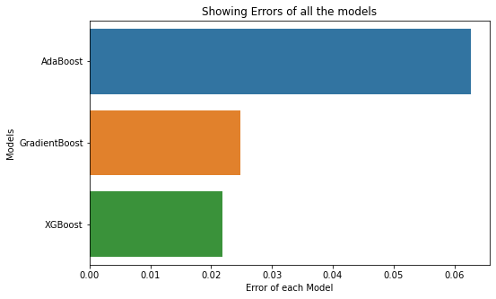

```python
plt.figure(figsize=(8, 5))
sns.barplot(x='Error', y='Models', data=boosting_models_df, orient='h')
plt.title("Showing Errors of all the models")
plt.xlabel('Error of each Model')
plt.ylabel('Models')
plt.show()
```

### Model Improvement - Boosting

```python
improved_adaBoost_regressor = AdaBoostRegressor(n_estimators=1000, learning_rate=0.001, loss='linear')
improved_gradientBoost_regressor = GradientBoostingRegressor(n_estimators=1200, learning_rate=0.1, loss='huber')
improved_xgboost_regressor = XGBRegressor(n_estimators=1800, learning_rate=0.01)


improved_adaBoost_regressor.fit(x_train, y_train)
improved_gradientBoost_regressor.fit(x_train, y_train)
improved_xgboost_regressor.fit(x_train, y_train)


improved_adaBoost_prediction = improved_adaBoost_regressor.predict(x_test)
improved_gradientBoost_prediction = improved_gradientBoost_regressor.predict(x_test)
improved_xgboost_prediction = improved_xgboost_regressor.predict(x_test)


print('mean_absolute_error for AdaBoost Regressor     : ', mean_absolute_error(y_test, improved_adaBoost_prediction))
print('mean_absolute_error for GradientBoost Regressor: ', mean_absolute_error(y_test, improved_gradientBoost_prediction))
print('mean_absolute_error for XGBoost Regressor: ', mean_absolute_error(y_test, improved_xgboost_prediction))
```

```
mean_absolute_error for AdaBoost Regressor     :  0.05855364736034522
mean_absolute_error for GradientBoost Regressor:  0.013811638229518745
mean_absolute_error for XGBoost Regressor:  0.018769374516191262
```

```python
print('mean_absolute_error for AdaBoost Regressor     : ', mean_absolute_error(y_test, improved_adaBoost_prediction))
print('mean_absolute_error for GradientBoost Regressor: ', mean_absolute_error(y_test, improved_gradientBoost_prediction))
print('mean_absolute_error for XGBoost Regressor: ', mean_absolute_error(y_test, improved_xgboost_prediction))
```

```
mean_absolute_error for AdaBoost Regressor     :  0.05855364736034522
mean_absolute_error for GradientBoost Regressor:  0.013811638229518745
mean_absolute_error for XGBoost Regressor:  0.018769374516191262
```

```python
improved_boosting_models_dict = {"Models": ['AdaBoost', 'GradientBoost', 'XGBoost'],
                        'Error': [mean_absolute_error(y_test, improved_adaBoost_prediction),
                                  mean_absolute_error(y_test, improved_gradientBoost_prediction),
                                  mean_absolute_error(y_test, improved_xgboost_prediction)]}

improved_boosting_models_df = pd.DataFrame(improved_boosting_models_dict)

improved_boosting_models_df
```

|  | Models | Error |
| --- | --- | --- |
| 0 | AdaBoost | 0.058554 |
| 1 | GradientBoost | 0.013812 |
| 2 | XGBoost | 0.018769 |

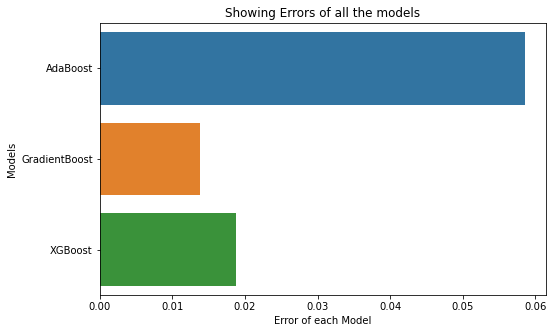

```python
plt.figure(figsize=(8, 5))
sns.barplot(x='Error', y='Models', data=improved_boosting_models_df, orient='h')
plt.title("Showing Errors of all the models")
plt.xlabel('Error of each Model')
plt.ylabel('Models')
plt.show()
```

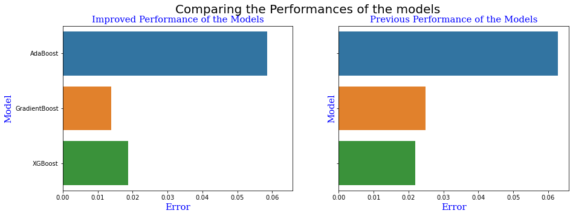

```python
fig, axes = plt.subplots(1, 2, figsize=(15, 5), sharey=True, sharex=True)
fig.suptitle('Comparing the Performances of the models', fontsize = 20, x=0.5, fontweight=500)

font1 = {'family':'serif','color':'blue','size':15}

sns.barplot(ax=axes[0], x='Error', y='Models', data = improved_boosting_models_df, orient='h')
axes[0].set_title("Improved Performance of the Models", fontdict = font1)
axes[0].set_xlabel('Error', fontdict=font1)
axes[0].set_ylabel('Model', fontdict=font1)
# axes[0].xla

# plt.subplot(1, 2, 2)
sns.barplot(ax=axes[1], x='Error', y='Models', data = boosting_models_df, orient='h')
axes[1].set_title("Previous Performance of the Models", fontdict = font1)
axes[1].set_xlabel('Error', fontdict=font1)
axes[1].set_ylabel('Model', fontdict=font1)
plt.show()
```

The improvement in the performance of the model can be clearly seen in the above graph. The graph on the left side is showing the performance of the tuned models that is why the length of the bars is less than that on the right.